# HAR Practical Machine Learning: Qualitative Weight Lifting Study

M.N.L

1/15/2021

## Executive Summary

Using a wide variety of devices such as Jawbones and Fitbit, individuals take measurements of their activities so as to improve their health, measure their behavior or just because they are fascinated with new tech gadgets. To investigate how well a weight lifting activity is done, a qualitative study was conducted on 6 subjects by measuring different features that characterize a weight lifting activity. The study involved taking 10 repeated measurements for 5 different weight lifting movements of which 4 of the activities are wrong and one is correct. The five movements included “(Class A), throwing the elbows to the front (Class B), lifting the dumbbell only halfway (Class C), lowering the dumbbell only halfway (Class D) and throwing the hips to the front (Class E)”.

The data set consisted of approximately 20000 observations for 160 feature variables. The following steps were used to arrive at the final model

1. The first step involved cleaning the data, and then selecting the appropriate variables
2. Next, an exploratory analysis of the selected data variables was performed
3. The performance of two cross validation methods was then evaluated
4. The best cross validation method was selected and used to compare the performance of several machine models 5.The accuracy of each model was compared, and the best model was chosen to predict the test data.

### Analysis

#### Cleaning The Data

Predictor variables obtained from the measurements taken by the accelerometers were selected. The total number of missing values in each column column was calculated and all predictor variables with a large number of missing values were deleted.

```r
library(ggplot2); library(caret); library(readr); library(dplyr); library(reshape2);library(plotly); library(magrittr);library(corrplot);library(kableExtra)

HAR_training<-read_csv("https://d396qusza40orc.cloudfront.net/predmachlearn/pml-training.csv")
HAR_testing<-read_csv("https://d396qusza40orc.cloudfront.net/predmachlearn/pml-testing.csv")


#Subset data with accelerometer
classe<-as.factor(HAR_training$classe)
HAR_training<-HAR_training[, grepl("acc", names(HAR_training))]
HAR_testing<- HAR_testing[, grepl("acc", names(HAR_testing))]
ht<-data.frame(HAR_training, classe)

#Identifing the number of NAs in training columns
n_missing<-t(data.frame(colSums(is.na(ht))))

#Deleting columns with a large number of NA values
ht<- ht[, c(-2,-7,-12,-17)]
HAR_testing<-HAR_testing[, c(-2,-7,-12,-17)]
```

#### Exploratory Analysis

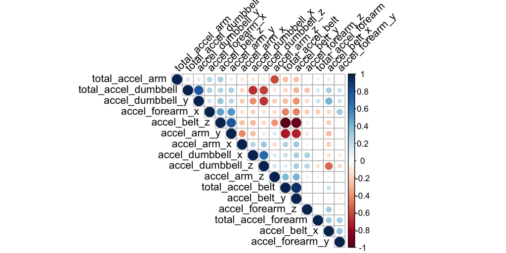

```r
cordata<- as.matrix(cor(ht[,-17]) )
corrplot(cordata, type = "upper", order = "hclust",
         tl.col = "black", tl.srt = 45)
```

```r
set.seed(125)

#Create cross_validation from training set
inTrain = createDataPartition(ht$classe, p = 3/4)[[1]]
training = ht[ inTrain,]
cv = ht[-inTrain,]

model1<-train(classe~.,method='rf', data=training)
rf_pred<-predict(model1,cv )
table1_r<-table(rf_pred,cv$classe)
c_rf<-confusionMatrix(table1_r)
accuracy_rf<-confusionMatrix(table1_r)$overall["Accuracy"]
kbl(c_rf$table) %>%
  kable_styling(bootstrap_options = "striped", full_width = F, position = "center")
```

|  | A | B | C | D | E |
| --- | --- | --- | --- | --- | --- |
| A | 1341 | 42 | 11 | 7 | 3 |
| B | 10 | 867 | 18 | 4 | 12 |
| C | 23 | 28 | 816 | 30 | 4 |
| D | 21 | 7 | 9 | 762 | 5 |
| E | 0 | 5 | 1 | 1 | 877 |

```r
kbl(c_rf$overall) %>%
  kable_styling(bootstrap_options = "striped", full_width = F, position = "center")
```

|  | x |
| --- | --- |
| Accuracy | 0.9508564 |
| Kappa | 0.9378386 |
| AccuracyLower | 0.9444305 |
| AccuracyUpper | 0.9567385 |
| AccuracyNull | 0.2844617 |
| AccuracyPValue | 0.0000000 |
| McnemarPValue | 0.0000000 |

```r
set.seed(125)
tr_ctrl<-trainControl(method = "cv", number=5)
model1_k<-train(classe~.,method='rf', trcontrol="tr_ctrl", data=training)
confusionMatrix(model1_k)
```

```
## Bootstrapped (25 reps) Confusion Matrix
##
## (entries are percentual average cell counts across resamples)
##
##           Reference
## Prediction    A    B    C    D    E
##          A 27.4  0.8  0.4  0.5  0.1
##          B  0.2 17.2  0.6  0.1  0.3
##          C  0.4  0.7 16.2  0.8  0.2
##          D  0.5  0.2  0.2 14.9  0.3
##          E  0.0  0.2  0.0  0.1 17.6
##
##  Accuracy (average) : 0.9334
```

### Model Analysis

The Random Forest Model was then compared with 3 additional models - Boosting method, Linear Discriminant Analysis Method and the Stacking Method. The overall accuracy for the Boosting method is as follows:

```r
model2<-train(classe~.,method='gbm', data=training, verbose=FALSE)
gbm_pred<-predict(model2,cv)
table1_g<-table(gbm_pred,cv$classe)
c_g<-confusionMatrix(table1_g)
accuracy_g<-confusionMatrix(table1_g)$overall["Accuracy"]
kbl(c_g$overall) %>%
  kable_styling(bootstrap_options = "striped", full_width = F, position = "center")
```

|  | x |
| --- | --- |
| Accuracy | 0.8313622 |
| Kappa | 0.7862622 |
| AccuracyLower | 0.8205841 |
| AccuracyUpper | 0.8417441 |
| AccuracyNull | 0.2844617 |
| AccuracyPValue | 0.0000000 |
| McnemarPValue | 0.0000000 |

The overall accuracy for the Linear Discriminant Analysis is as follows

```r
model3<-train(classe~.,method='lda', data=training)
lda_pred<-predict(model3,cv)
table1_l<-table(lda_pred,cv$classe)
c_l<-confusionMatrix(table1_l)
accuracy_l<-confusionMatrix(table1_l)$overall["Accuracy"]
kbl(c_l$overall) %>%
  kable_styling(bootstrap_options = "striped", full_width = F, position = "center")
```

|  | x |
| --- | --- |
| Accuracy | 0.5193719 |
| Kappa | 0.3841008 |
| AccuracyLower | 0.5052784 |
| AccuracyUpper | 0.5334424 |
| AccuracyNull | 0.2844617 |
| AccuracyPValue | 0.0000000 |
| McnemarPValue | 0.0000000 |

Stacking method combined the predictor variables obtained from the 3 models and it used the random forest method to predict the new outcome. The overall accuracy is as follows

```r
pred_combo<-data.frame(rf_pred, gbm_pred, lda_pred, cv$classe)
comboModel<-train(cv.classe~., method='rf', data=pred_combo)
comboModel_p<-predict(comboModel,pred_combo)
table1_c<-table(comboModel_p,cv$classe)
c_c<-confusionMatrix(table1_c)
accuracy_c<-confusionMatrix(table1_c)$overall['Accuracy']
kbl(c_c$overall) %>%
  kable_styling(bootstrap_options = "striped", full_width = F, position = "center")
```

|  | x |
| --- | --- |
| Accuracy | 0.9508564 |
| Kappa | 0.9378386 |
| AccuracyLower | 0.9444305 |
| AccuracyUpper | 0.9567385 |
| AccuracyNull | 0.2844617 |
| AccuracyPValue | 0.0000000 |
| McnemarPValue | 0.0000000 |

The selection of the best model was based on accuracy and efficiency. As seen in the table below, the accuracy of the random forest method and the stacking method is equal, and the highest among the other models. The Random Forest method was chosen as the best model since it took less time to run.

```r
accuracy_comp<-data.frame("accuracy_rf"=c(accuracy_rf), "accuracy_g"=c(accuracy_g), "accuracy_l"=c(accuracy_l), "accuracy_c"=c(accuracy_c))
kbl(accuracy_comp) %>%
  kable_styling(bootstrap_options = "striped", full_width = F, position = "center")
```

|  | accuracy_rf | accuracy_g | accuracy_l | accuracy_c |
| --- | --- | --- | --- | --- |
| Accuracy | 0.9508564 | 0.8313622 | 0.5193719 | 0.9508564 |